# Data Mining and Text Mining - Quiz 5

Gus Lipkin - glipkin6737@floridapoly.edu

- Ref: CW_intro_topic_modeling-3-jj
- Ref: [Nov 30, 2021] CW_intro_topic_modeling-ex-post-4-jj

Run the code below to load the `tidyverse` package for data transformation and visualization, the `tidytext` package for tidy text mining, and the `topicmodels` package for using the Latent Dirichlet Allocation (LDA) method.

- Please install *topicdoc* package

```r
# install.packages('topicdoc')
library(topicdoc)
library(topicmodels)

library(tidyverse)
library(tidytext)
```

# Problem 1 (70 points)

Read the dataset for this exercise:

```r
text <- read_csv("https://github.com/reisanar/datasets/raw/master/poly_news_FL20.csv")
head(text)
```

| news_date | news_title | news_summary |
| --- | --- | --- |
| 2020-11-18 | Florida Poly Board of Trustees welcomes four new prominent appointments | LAKELAND, Fla. - Florida's Board of Governors appointed four distinguished and diverse members to the Florida Polytechnic University Board of Trustees. |
| 2020-11-18 | Professor's new program fund turns students' engineering ideas into reality | Dr. Muhammad Rashid's passion for education has driven his actions for more than 40 years. |
| 2020-11-11 | Hurricane Eta Updates | We are closely monitoring the path of Hurricane Eta as it continues to approach Florida and may impact our region. At this time, there are no changes to class schedules and the University will continu… |
| 2020-11-10 | Florida Poly Band arises and finds its groove | The Florida Polytechnic University Band made its performance debut at Phoenix Family Day on Oct. 17 in the Oak Groove. |
| 2020-11-05 | Clubs energized by Student Development collaboration | Health restrictions and challenges posed by COVID-19 haven't stopped student clubs from making the most out of the fall semester. A new push by the Office of Student Development is reinforcing student… |
| 2020-11-04 | Capstone team works to improve critical medical sample transportation | Testing of biological samples for COVID-19 and other medical purposes relies upon the samples being held at the right temperature until the test can be completed. Maintaining this stable environment c… |

### Q1-1 (10 points): Perform tokenization and count:

- Please do tokenization, stopword removal, count, and ungroup()
- text data comes from **news_summary column**

```r
text_count <- text %>%
  unnest_tokens(word, news_summary) %>%
  anti_join(stop_words) %>%
  count(news_title, word) %>%
  ungroup()
head(text_count)
```

| news_title | word | n |
| --- | --- | --- |
| '20 Florida Poly alum springboards to dream career in cybersecurity | 20 | 1 |
| '20 Florida Poly alum springboards to dream career in cybersecurity | analyst | 1 |
| '20 Florida Poly alum springboards to dream career in cybersecurity | bryan | 1 |
| '20 Florida Poly alum springboards to dream career in cybersecurity | culmination | 1 |
| '20 Florida Poly alum springboards to dream career in cybersecurity | dedication | 1 |
| '20 Florida Poly alum springboards to dream career in cybersecurity | happier | 1 |

### Q1-2 (10 points) Document-term matrix:

- Right now our data frame word_counts is in a tidy form, with one-term-per-document-per-row, but the topicmodels package requires a DocumentTermMatrix. We can cast a one-token-per-row table into a `DocumentTermMatrix` with `tidytext`’s function `cast_dtm()`.

Use `cast_dtm()`:

```r
text_dtm <- text_count %>%
  cast_dtm(news_title, word, n)

head(text_dtm)
```

```
<<DocumentTermMatrix (documents: 6, terms: 1667)>>
Non-/sparse entries: 92/9910
Sparsity           : 99%
Maximal term length: NA
Weighting          : term frequency (tf)
```

### Q1-3 (10 points) Applying LDA with topic 4

- Please set seed as 4, seed=4

```r
text_lda_topic_4 <- LDA(text_dtm, k = 4, seed = 4)
text_lda_topic_4
```

```
A LDA_VEM topic model with 4 topics.
```

# Diagnostic of LDA with topic 4 results

### Q1-4 (10 points) Top 7 words in each topics

- using **terms** method

```r
terms(text_lda_topic_4, 7)
```

```
     Topic 1       Topic 2       Topic 3       Topic 4
[1,] "florida"     "florida"     "florida"     "university"
[2,] "university"  "university"  "university"  "florida"
[3,] "polytechnic" "polytechnic" "polytechnic" "polytechnic"
[4,] "lakeland"    "students"    "students"    "students"
[5,] "fla"         "campus"      "19"          "19"
[6,] "science"     "semester"    "covid"       "covid"
[7,] "student"     "lakeland"    "community"   "student"
```

### Q1-5 (10 points) Word-topic probabilities

- Extract the `beta`s (word-topic probabilities)

```r
text_review_lda_topic_4 <- tidy(text_lda_topic_4, "beta")
text_review_lda_topic_4
```

| topic | term | beta |
| --- | --- | --- |
| 1 | 20 | 1.218852e-03 |
| 2 | 20 | 1.070040e-03 |
| 3 | 20 | 1.358539e-242 |
| 4 | 20 | 2.920532e-03 |
| 1 | analyst | 3.115003e-248 |
| 2 | analyst | 2.107633e-248 |
| 3 | analyst | 1.479719e-248 |
| 4 | analyst | 9.735105e-04 |
| 1 | bryan | 1.190799e-247 |
| 2 | bryan | 1.813008e-248 |

[output cut: 990 more lines]

### Q1-6 (10 points) Document-topic probabilities

- Extract the `gamma`s (Document-topic probabilities)

```r
text_review_lda_topic_4 <- tidy(text_lda_topic_4, "gamma")
text_review_lda_topic_4
```

| document | topic | gamma |
| --- | --- | --- |
| '20 Florida Poly alum springboards to dream career in cybersecurity | 1 | 0.0016777706 |
| "Crazy idea" leads Florida Poly students to take on the technology services market | 1 | 0.0013649061 |
| 2019 Florida Poly look back | 1 | 0.9965488411 |
| 2020 grad working to revolutionize high-tech crop harvesting | 1 | 0.0019804033 |
| 2020 graduate builds next generation of esports champs | 1 | 0.0009941392 |
| 2020 graduate ready to make impact in computer science | 1 | 0.9940587901 |
| 6th annual Florida Poly Pi Run goes virtual for July 4 weekend | 1 | 0.0006441707 |
| Accusoft and students connect in virtual campus visit | 1 | 0.0012850302 |
| Additional safety precautions for on-campus residents | 1 | 0.0030980386 |
| Addressing campus resiliency | 1 | 0.0013649061 |

[output cut: 710 more lines]

### Q1-7 (10 points) All the diagnostics at once using **topic_diagnostics**

- ref: https://cran.r-project.org/web/packages/topicdoc/vignettes/basic_usage.html
- using **topic_diagnostics**

```r
topic_diagnostics(text_lda_topic_4, text_dtm)
```

| topic_num | topic_size | mean_token_length | dist_from_corpus | tf_df_dist | doc_prominence | topic_coherence | topic_exclusivity |
| --- | --- | --- | --- | --- | --- | --- | --- |
| 1 | 405.0014 | 7.4 | 0.5834577 | 1.349087 | 43 | -114.59453 | 8.610163 |
| 2 | 414.6978 | 6.9 | 0.5436011 | 1.253233 | 48 | -97.84332 | 8.354644 |
| 3 | 389.8664 | 6.8 | 0.5776656 | 1.289182 | 39 | -86.48504 | 8.603547 |
| 4 | 457.4343 | 6.5 | 0.5311495 | 1.317866 | 62 | -111.84571 | 8.213508 |

# Problem 2 (30 points)

- Ref: [Nov 30, 2021] CW_intro_topic_modeling-ex-post-4-jj

### Q2-1 (10 points) Average of topic_coherence for topic 4 LDA

- what is the average of topic_coherence for topic 4 LDA : (please answer)

*Q2-1 (option 1) using topic_diagnostics, selecet, colMean()

```r
topic_diagnostics(text_lda_topic_4, text_dtm) %>%
  select(topic_coherence) %>%
  colMeans()
```

```
topic_coherence
      -102.6921
```

## Average of topic_coherence for topic 4 LDA with manual functions

- Q2-1 (option 2) using a manual function for average coherence score

#### same thing but with its own function

```r
JJ_wanna_know_average_topic_coherence <- function(your_lda, your_dtm_textdata) {
  average_topic_coherence <- topic_diagnostics(your_lda, your_dtm_textdata) %>%
    select(topic_coherence) %>%
    colMeans()
  print('Average topic cohence ---')
  print(average_topic_coherence[1])
}

JJ_wanna_know_average_topic_coherence(text_lda_topic_4, text_dtm)
```

```
[1] "Average topic cohence ---"
topic_coherence
      -102.6921
```

#### (Just run) own function for the variance of topic coherence

```r
JJ_wanna_know_variance_topic_coherence <- function(your_lda, your_dtm_textdata) {
  variance_topic_coherence <-topic_diagnostics(your_lda, your_dtm_textdata) %>%
  select(topic_coherence) %>%
  var()
  print('Variance topic cohence ---')
  print(variance_topic_coherence[1])
}


JJ_wanna_know_variance_topic_coherence(text_lda_topic_4, text_dtm)
```

```
[1] "Variance topic cohence ---"
[1] 170.5453
```

#### (Just run) own function for average and variance of topic coherence

```r
JJ_wanna_know_average_and_variance_topic_coherence_at_once<- function(your_lda, your_dtm_textdata) {
  avg <- JJ_wanna_know_average_topic_coherence(your_lda, your_dtm_textdata)
  var <- JJ_wanna_know_variance_topic_coherence(your_lda, your_dtm_textdata)
  return(avg[1])
  }

JJ_wanna_know_average_and_variance_topic_coherence_at_once(text_lda_topic_4, text_dtm)
```

```
[1] "Average topic cohence ---"
topic_coherence
      -102.6921
[1] "Variance topic cohence ---"
[1] 170.5453
topic_coherence
      -102.6921
```

# Q2-2 (20 points) Optimal topic number selection after run

- using following functions (JJ_all_one_function)
- What are the optimal number of topic numbers based on the average coherence score and why? (answer)
- run LDA with different topics numbers from 2 to 7, please use the following function **_JJ_all_one_function**

## Just run

```r
score_list <- c()

JJ_all_one_function <-function(your_dtm, topic_num){
   for (i in 2:topic_num) {
     score_list <- append(score_list,
                          JJ_wanna_know_average_and_variance_topic_coherence_at_once(LDA(your_dtm,
                                                                                         k=i,
                                                                                         control=list(seed=i)),
                                                                                     your_dtm))
   }
  return(score_list)
}

score_list_output <- JJ_all_one_function(text_dtm, 7)
```

```
[1] "Average topic cohence ---"
topic_coherence
      -114.2796
[1] "Variance topic cohence ---"
[1] 527.4196
[1] "Average topic cohence ---"
topic_coherence
      -110.7978
[1] "Variance topic cohence ---"
[1] 199.5422
[1] "Average topic cohence ---"
topic_coherence
      -105.1026
[1] "Variance topic cohence ---"
[1] 104.6486
[1] "Average topic cohence ---"
topic_coherence
      -106.1395
[1] "Variance topic cohence ---"
[1] 82.62387
[1] "Average topic cohence ---"
topic_coherence
      -109.3539
[1] "Variance topic cohence ---"
[1] 89.90835
[1] "Average topic cohence ---"
topic_coherence
      -109.1739
[1] "Variance topic cohence ---"
[1] 25.98621
```

```r
score_list_output
```

```
topic_coherence topic_coherence topic_coherence topic_coherence topic_coherence topic_coherence
      -114.2796       -110.7978       -105.1026       -106.1395       -109.3539       -109.1739
```

### Just run after the above code

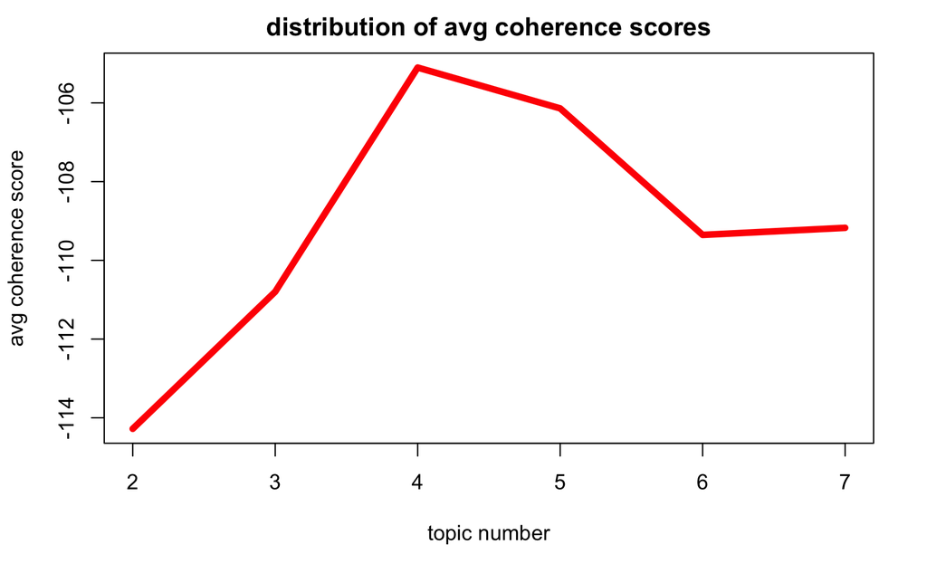

```r
plot(
  x = 2:7,
  y = score_list_output,
  type = "l",
  col = "red",
  lwd = 5,
  xlab = "topic number",
  ylab = "avg coherence score",
  main = "distribution of avg coherence scores"
)
```

> Four topics seems to be the right amount as they are more cohesive as indicated by a score closer to zero.